# Practical Lab 8 - MNIST Classification with Dense Neural Networks

## 9000400

## Introduction:

This notebook focuses on evaluating a machine learning model using the Fashion MNIST dataset. We will train the model to classify different types of clothing items, then assess its performance through metrics like accuracy, precision, recall, and F1-score on both validation and test datasets.

### Load the data

```python
from tensorflow.keras.datasets import mnist
from tensorflow import keras
from tensorflow.keras import layers
import tensorflow as tf
```

```
WARNING:tensorflow:From c:\Users\marya\Documents\Courses\Cscn8010\class_Notbook\venv\CSCN8010_classic_ml\Lib\site-packages\keras\src\losses.py:2976: The name tf.losses.sparse_softmax_cross_entropy is deprecated. Please use tf.compat.v1.losses.sparse_softmax_cross_entropy instead.
```

```python
import numpy as np
import pandas as pd

# Load the dataset
train_df = pd.read_csv('.\\data\\fashion-mnist_train.csv')
test_df = pd.read_csv('.\\data\\fashion-mnist_test.csv')

# Separate features and labels
X_train = train_df.drop('label', axis=1).values
y_train = train_df['label'].values

X_test = test_df.drop('label', axis=1).values
y_test = test_df['label'].values

# Normalize the data to have values between 0 and 1
X_train = X_train / 255.0
X_test = X_test / 255.0
# X_train =X_train.reshape((60000, 28 * 28))  # flattening the 28x28 image into dim=1 (784,) vector (and over all images in the training set)
# X_test = X_test.reshape((10000, 28 * 28))
```

### EDA

Fashion-MNIST is a dataset of Zalando's article images—consisting of a training set of 60,000 examples and a test set of 10,000 examples. Each example is a 28x28 grayscale image, associated with a label from 10 classes.

Here's an example of how the data looks (each class takes three-rows):

[figure not shown]

Source:https://www.kaggle.com/code/waalbannyantudre/fashion-mnist-classification-with-keras

```python
# lets first see the shape of the data
print("xtrain shape :",X_train.shape)
print("ytrain shape :",y_train.shape)
print("xtest shape :",X_test.shape)
print("ytest shape :",y_test.shape)
```

```
xtrain shape : (60000, 784)
ytrain shape : (60000,)
xtest shape : (10000, 784)
ytest shape : (10000,)
```

#### Sample Images with Labels

Displaying a set of images with their corresponding labels can help understand the complexity and variability within classes.

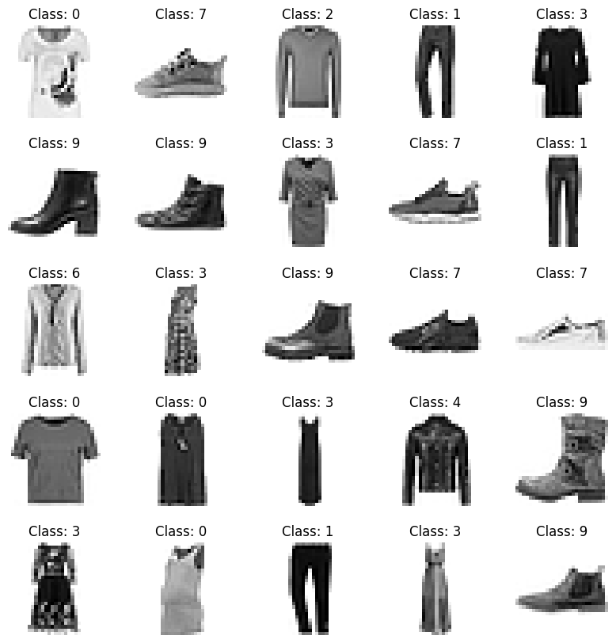

```python
fig, axes = plt.subplots(5, 5, figsize=(10, 10))
axes = axes.ravel()

for i in np.arange(0, 25):
    index = np.random.randint(0, len(X_train))
    axes[i].imshow(X_train[index].reshape(28, 28), cmap=plt.cm.binary)
    axes[i].set_title(f'Class: {y_train[index]}', fontsize=12)
    axes[i].axis('off')
plt.subplots_adjust(hspace=0.4)
```

#### Distribution of Classes

Check the balance of classes to see if the dataset is skewed towards certain classes, which might affect model performance.

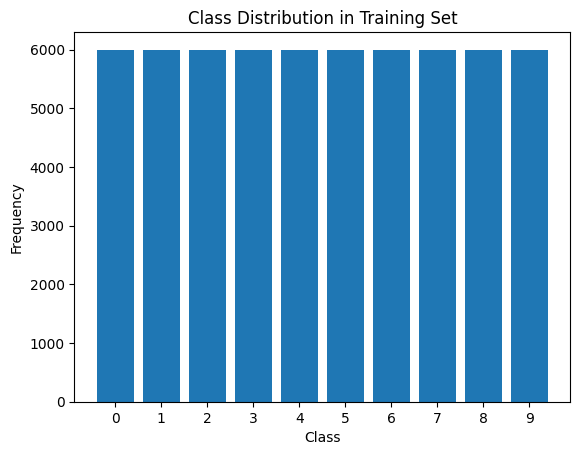

```python
import matplotlib.pyplot as plt

# Count the number of instances per class
unique, counts = np.unique(y_train, return_counts=True)
plt.bar(unique, counts)
plt.title('Class Distribution in Training Set')
plt.xlabel('Class')
plt.ylabel('Frequency')
plt.xticks(unique)
plt.show()
```

Below code shows sample of images and to which class it belongs

source:https://www.kaggle.com/code/waalbannyantudre/fashion-mnist-classification-with-keras?scriptVersionId=164423377&cellId=30

```python
# dictionary for each type of label
labels = {0 : "T-shirt/top", 1: "Trouser", 2: "Pullover", 3: "Dress", 4: "Coat",
          5: "Sandal", 6: "Shirt", 7: "Sneaker", 8: "Bag", 9: "Ankle Boot"}
def sample_images_data(data):
    # An empty list to collect some samples
    sample_images = []
    sample_labels = []

    # Iterate over the keys of the labels dictionary defined in the above cell
    for k in labels.keys():
        # Get four samples for each category
        samples = data[data["label"] == k].head(4)
        # Append the samples to the samples list
        for j, s in enumerate(samples.values):
            # First column contain labels, hence index should start from 1
            img = np.array(samples.iloc[j, 1:]).reshape(28, 28)
            sample_images.append(img)
            sample_labels.append(samples.iloc[j, 0])

    print("Total number of sample images to plot: ", len(sample_images))
    return sample_images, sample_labels

train_sample_images, train_sample_labels = sample_images_data(train_df)
```

```
Total number of sample images to plot:  40
```

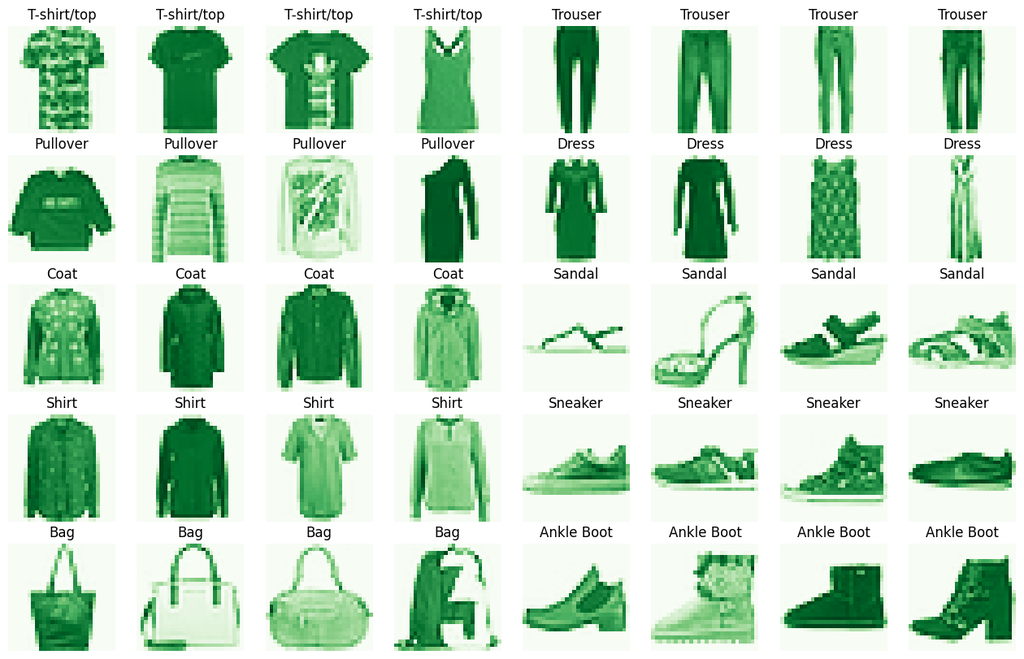

```python
def plot_sample_images(data_sample_images,data_sample_labels,cmap="Blues"):
    # Plot the sample images now
    f, ax = plt.subplots(5,8, figsize=(16,10))

    for i, img in enumerate(data_sample_images):
        ax[i//8, i%8].imshow(img, cmap=cmap)
        ax[i//8, i%8].axis('off')
        ax[i//8, i%8].set_title(labels[data_sample_labels[i]])
    plt.show()

plot_sample_images(train_sample_images,train_sample_labels, "Greens")
```

Below codes show each class or picture in matrix of 28 by 28 .and how the pixal are distibruted to present a spisific image.  
Source: https://github.com/CSCN8010/CSCN8010/blob/main/class_notebooks/datasets/mnist.ipynb

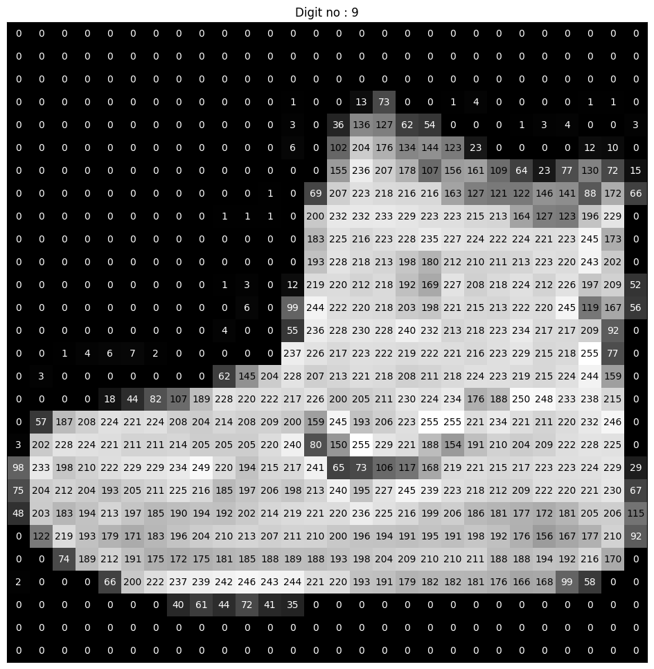

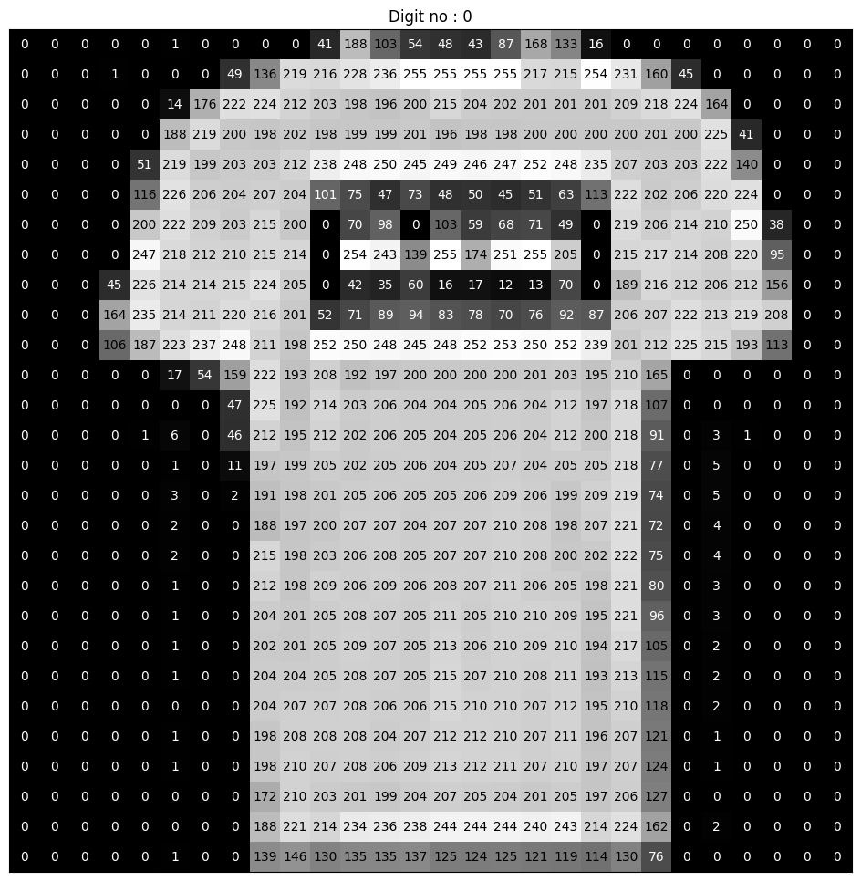

```python
def visualize_input(i, ax, y):
    img = X_train[i].reshape(28,28)
    ax.imshow(img, cmap='gray')
    ax.set_title(f"Digit no : {y[i]}")
    width, height = img.shape
    thresh = img.max()/2.5
    for x in range(width):
        for y in range(height):
            ax.annotate(str(img[x][y]), xy=(y,x),
                        horizontalalignment='center',
                        verticalalignment='center',
                        color='white' if img[x][y]<thresh else 'black')
    ax.set_xticks([])
    ax.set_yticks([])
for i in range(2):
    fig = plt.figure(figsize = (12,12))
    ax = fig.add_subplot(111)
    visualize_input(i, ax, y_train)
```

the digit no 9 its look like a shoes or boot. but digit no 0 , it is not clear at all. lets try it defrent way to see to which class it belong

below code has a function that we ca give any digit and it will show us the pictuer,it fun how the difrent picture is showing  
source: https://www.kaggle.com/code/m0hand/fashion-mnist-cnn?scriptVersionId=165412487&cellId=10

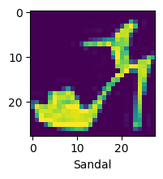

```python
def image_show(X, y, index):
    plt.figure(figsize = (15,2))
    plt.imshow(X[index])
    plt.xlabel(classes[y[index]])
image_show(X_train,y_train , 9)
classes = ["T-shirt/top","Trouser","Pullover","Dress","Coat","Sandal","Shirt","Sneaker","Bag","Ankle boot"]
```

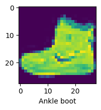

```python
def image_show(X, y, index):
    plt.figure(figsize = (15,2))
    plt.imshow(X[index])
    plt.xlabel(classes[y[index]])
image_show(X_train,y_train , 0)
```

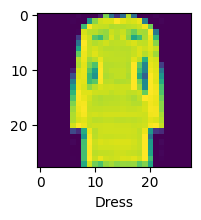

```python
def image_show(X, y, index):
    plt.figure(figsize = (15,2))
    plt.imshow(X[index])
    plt.xlabel(classes[y[index]])
image_show(X_train,y_train , 500)
```

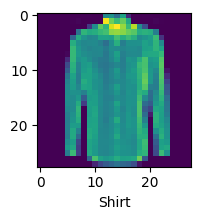

```python
def image_show(X, y, index):
    plt.figure(figsize = (15,2))
    plt.imshow(X[index])
    plt.xlabel(classes[y[index]])
image_show(X_train,y_train , 3000)
```

so in the codes above,it was nice to have some colores on pixals, make the pictures more attractive.

## Define Model

defining and training a fully-connected feedforward neural network using Keras and TensorFlow: we will create a simple but effective neural network for the Fashion MNIST dataset. The network will consist of an input layer, several hidden layers, and an output layer. We'll use ReLU (Rectified Linear Unit) as the activation function for hidden layers due to its effectiveness and simplicity, and softmax for the output layer to handle multi-class classification.

```python
model = keras.Sequential([
    layers.Dense(512, activation="relu"),
    layers.Dense(10, activation="softmax")
])
```

```
WARNING:tensorflow:From c:\Users\marya\Documents\Courses\Cscn8010\class_Notbook\venv\CSCN8010_classic_ml\Lib\site-packages\keras\src\backend.py:873: The name tf.get_default_graph is deprecated. Please use tf.compat.v1.get_default_graph instead.
```

```python
model.compile(optimizer="rmsprop",
              loss="sparse_categorical_crossentropy",
              metrics=["accuracy"])
```

```
WARNING:tensorflow:From c:\Users\marya\Documents\Courses\Cscn8010\class_Notbook\venv\CSCN8010_classic_ml\Lib\site-packages\keras\src\optimizers\__init__.py:309: The name tf.train.Optimizer is deprecated. Please use tf.compat.v1.train.Optimizer instead.
```

## Training ("Fitting") the model

Train the model on the training data. Here, we'll use a validation split of 20% to monitor the model's performance on unseen data during training.

```python
from sklearn.model_selection import train_test_split

# Split the data into training and validation sets
X_train, X_val, y_train, y_val = train_test_split(X_train, y_train, test_size=0.2, random_state=42)


history = model.fit(X_train, y_train, epochs=10,batch_size=100, validation_data=(X_val, y_val))
```

```
WARNING:tensorflow:From c:\Users\marya\Documents\Courses\Cscn8010\class_Notbook\venv\CSCN8010_classic_ml\Lib\site-packages\keras\src\utils\tf_utils.py:492: The name tf.ragged.RaggedTensorValue is deprecated. Please use tf.compat.v1.ragged.RaggedTensorValue instead.

WARNING:tensorflow:From c:\Users\marya\Documents\Courses\Cscn8010\class_Notbook\venv\CSCN8010_classic_ml\Lib\site-packages\keras\src\engine\base_layer_utils.py:384: The name tf.executing_eagerly_outside_functions is deprecated. Please use tf.compat.v1.executing_eagerly_outside_functions instead.
```

```python
# Generate predictions for the validation set
predictions = model.predict(X_val)
predicted_classes = np.argmax(predictions, axis=1)
```

```python
predictions
```

```
array([[1.2757710e-08, 6.3404122e-09, 2.6732856e-08, ..., 9.9997115e-01,
        1.3339979e-05, 1.0788033e-05],
       [2.3160982e-11, 1.0269490e-15, 4.8403978e-13, ..., 2.6078107e-12,
        1.0000000e+00, 4.3334396e-16],
       [2.4043499e-07, 2.0601887e-07, 5.8966549e-08, ..., 2.0679089e-07,
        9.9999809e-01, 3.9683616e-07],
       ...,
       [3.3330888e-08, 1.8735298e-09, 2.3027398e-10, ..., 1.8291332e-01,
        5.6397943e-07, 8.1708604e-01],
       [1.0445394e-05, 6.6291921e-07, 3.0054844e-05, ..., 6.2234892e-04,
        1.1664764e-05, 7.6445422e-06],
       [3.9011966e-13, 2.7610003e-18, 4.4933237e-18, ..., 1.3157457e-13,
        3.4747602e-15, 3.0493394e-12]], dtype=float32)
```

### Model Evaluation

```python
from sklearn.metrics import accuracy_score, precision_score, recall_score, f1_score,classification_report

# Calculate metrics
accuracy = accuracy_score(y_val, predicted_classes)
precision = precision_score(y_val, predicted_classes, average='weighted')
recall = recall_score(y_val, predicted_classes, average='weighted')
f1 = f1_score(y_val, predicted_classes, average='weighted')

# Print metrics
print(f"Accuracy: {accuracy}")
print(f"Precision: {precision}")
print(f"Recall: {recall}")
print(f"F1-Score: {f1}")

# For a detailed classification report
print("\nClassification Report:\n", classification_report(y_val, predicted_classes))
```

```
Accuracy: 0.88875
Precision: 0.8879891864729007
Recall: 0.88875
F1-Score: 0.886870725476487

Classification Report:
               precision    recall  f1-score   support

           0       0.80      0.88      0.84      1232
           1       0.99      0.97      0.98      1174
           2       0.79      0.85      0.82      1200
           3       0.88      0.92      0.90      1242
           4       0.81      0.78      0.79      1185
           5       0.97      0.96      0.96      1141
           6       0.79      0.62      0.70      1243
           7       0.94      0.97      0.96      1224
           8       0.94      0.99      0.96      1149
           9       0.98      0.96      0.97      1210

    accuracy                           0.89     12000
   macro avg       0.89      0.89      0.89     12000
weighted avg       0.89      0.89      0.89     12000
```

### Predictions on the Test Set

for running the model on the test set , First, we use trained model to predict the classes of the test set

```python
# Generate predictions for the test set
test_predictions = model.predict(X_test)
test_predicted_classes = np.argmax(test_predictions, axis=1)
```

And then we can evaluate Model Performance on test data

```python
# Calculate metrics
test_accuracy = accuracy_score(y_test, test_predicted_classes)
test_precision = precision_score(y_test, test_predicted_classes, average='weighted')
test_recall = recall_score(y_test, test_predicted_classes, average='weighted')
test_f1 = f1_score(y_test, test_predicted_classes, average='weighted')

# Print metrics
print(f"Test Accuracy: {test_accuracy}")
print(f"Test Precision: {test_precision}")
print(f"Test Recall: {test_recall}")
print(f"Test F1-Score: {test_f1}")

# For a detailed classification report
print("\nClassification Report:\n", classification_report(y_test, test_predicted_classes))
```

```
Test Accuracy: 0.8893
Test Precision: 0.8887880845562993
Test Recall: 0.8893
Test F1-Score: 0.8879246876130029

Classification Report:
               precision    recall  f1-score   support

           0       0.80      0.88      0.84      1000
           1       0.98      0.98      0.98      1000
           2       0.79      0.83      0.81      1000
           3       0.91      0.91      0.91      1000
           4       0.83      0.81      0.82      1000
           5       0.98      0.94      0.96      1000
           6       0.78      0.64      0.70      1000
           7       0.92      0.96      0.94      1000
           8       0.95      0.98      0.97      1000
           9       0.96      0.95      0.95      1000

    accuracy                           0.89     10000
   macro avg       0.89      0.89      0.89     10000
weighted avg       0.89      0.89      0.89     10000
```

### Increasing Precision and Reacall

generally for increasing accuracy in neurons network we can manullay optimize the hyperparameters ,like batch sizes, epochs, number of neurons and number of layers. however as we requsted to the increase the precision for class '5' without changing the model or retraining. so in this case i will try to change the threshold

```python
# Custom threshold for class '5'
threshold_for_5 = 0.7  # Increase this threshold to be more conservative

# Apply threshold to class '5' predictions
adjusted_predictions = np.argmax(predictions, axis=1)  # Default predictions
high_confidence_5 = predictions[:, 5] >= threshold_for_5  # Indices where class '5' prediction is above the threshold

# Adjust predictions based on the new threshold
adjusted_predictions[~high_confidence_5 & (adjusted_predictions == 5)] = -1  # Assign a new class (e.g., -1) if below threshold

# Calculate new precision (using scikit-learn)
from sklearn.metrics import precision_score
new_precision = precision_score(y_val, adjusted_predictions, labels=[5], average='micro')
print(f"New Precision for Class '5': {new_precision}")
```

```
New Precision for Class '5': 1.0
```

```python
# Lower the threshold for class '5' to increase recall
threshold_for_5 = 0.3  # Decrease this threshold to be more liberal

# Indices where class '5' prediction is above the (lower) threshold
high_confidence_5 = predictions[:, 5] >= threshold_for_5

# Adjust predictions to increase recall for class '5'
adjusted_predictions[high_confidence_5] = 5  # Assign class '5' if above the lower threshold

# Calculate new recall (using scikit-learn)
from sklearn.metrics import recall_score
new_recall = recall_score(y_val, adjusted_predictions, labels=[5], average='micro')
print(f"New Recall for Class '5': {new_recall}")
```

```
New Recall for Class '5': 1.0
```

# Lab 9 - Avoiding Overfitting by Saving a Model

## Introduction

This Jupyter Notebook explores the impact of varying neural network architectures and training parameters on model performance. Through the comparison of four distinct models, we investigate how changes in layer depth, neuron count, epochs, and batch sizes influence the ability to learn from training data and generalize to unseen data. The goal is to identify optimal configurations that balance learning efficiency with robust generalization, thereby enhancing model accuracy while avoiding overfitting. This systematic approach aids in understanding the nuances of neural network optimization.

### Step3.1: 3 different neural networks by changing the hyperparameter

### Step3.2: Plottting the training and validation loss and accuracy

### Step3.3: identify the best set of weights :

to identify the best set of weights based on minimizing overfitting and optimizing performance on unseen data, we look for the epoch where the validation loss is at its lowest. This is because the lowest validation loss indicates the point at which the model was best able to generalize to new data without overfitting to the training data.

**Note:**  
For better understanding I will do the 3 steps below the model each time

## 3.1 Model 1

### 3.1.1: Create Model 1

**Model 1: increasing the number of neurons:** I would like to start my exploration in changing hyperparameter, with increasing the number of neurons in the first layer:

```python
model1 = keras.Sequential([
    layers.Dense(1024, activation="relu"),
    layers.Dense(10, activation="softmax")
])

model1.compile(optimizer="rmsprop",
                loss="sparse_categorical_crossentropy",
                metrics=["accuracy"])
```

```python
# first we need to define a validation set
x_val = X_train[:10000]
partial_x_train = X_train[10000:]
y_val = y_train[:10000]
partial_y_train = y_train[10000:]
```

```python
history1 = model1.fit(partial_x_train,
                    partial_y_train,
                    epochs=20,
                    batch_size=128,
                    validation_data=(x_val, y_val))

history_dict = history1.history
history_dict.keys()
```

```
dict_keys(['loss', 'accuracy', 'val_loss', 'val_accuracy'])
```

### 3.1.2: plotting model 1

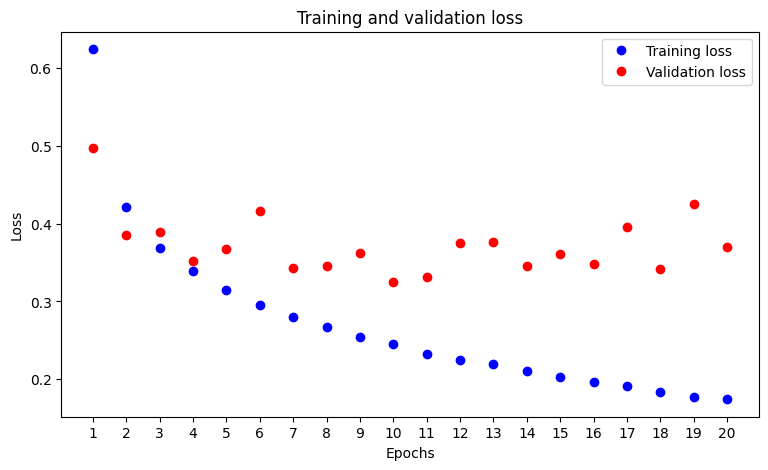

```python
# plot the training and validation loss
import matplotlib.pyplot as plt
plt.figure(figsize=(9, 5))
loss_values = history_dict["loss"]
val_loss_values = history_dict["val_loss"]
epochs = range(1, len(loss_values) + 1)
plt.plot(epochs, loss_values, "bo", label="Training loss")
plt.plot(epochs, val_loss_values, "ro", label="Validation loss")
plt.xlabel("Epochs")
plt.xticks(epochs)
plt.ylabel("Loss")
plt.legend()
plt.title("Training and validation loss")
```

[figure not shown]

```python
# plot the training and validation accuracy
import matplotlib.pyplot as plt
plt.figure(figsize=(9, 5))
loss_values = history_dict["accuracy"]
val_loss_values = history_dict["val_accuracy"]
epochs = range(1, len(loss_values) + 1)
plt.plot(epochs, loss_values, "bo", label="Training accuracy")
plt.plot(epochs, val_loss_values, "ro", label="Validation accuracy")
plt.xlabel("Epochs")
plt.xticks(epochs)
plt.ylabel("Accuracy")
plt.legend()
plt.title("Training and validation accuracy")
```

### 3.1.3: identify the best set of weights for model 1:

The best set of weights for the model corresponds to the end of epoch 10, where the validation loss reached its minimum value of 0.3245, indicating the optimal balance between learning from the training data and generalizing to the validation data. this is very clear in the plot. as we can see after epoch 10 the data in validation set start to get overfitting.

## 3.2 Model 2

### 3.2.1: Creating model 2:

in this model i will increase the number of hidden layers to 3 layers.al of them fully connected and activation function will be Relu. the numbers of neurons in first layers will be 512,second layers:256 and third layers:128.

```python
from tensorflow.keras.models import Sequential
from tensorflow.keras.layers import Dense, Dropout
from tensorflow.keras.optimizers import RMSprop
# Define the model
model2 = keras.Sequential([
   layers.Dense(512, activation="relu"),
   layers.Dense(256, activation="relu"),
    layers.Dense(128, activation="relu"),
    layers.Dense(10, activation="softmax")
])
```

```python
# Compile the model
model2.compile(optimizer=RMSprop(),
              loss='sparse_categorical_crossentropy',
              metrics=['accuracy'])
```

```python
history2 = model2.fit(partial_x_train,
                    partial_y_train,
                    epochs=20,
                    batch_size=128,
                    validation_data=(x_val, y_val))

history_dict2 = history2.history
history_dict2.keys()
```

```
dict_keys(['loss', 'accuracy', 'val_loss', 'val_accuracy'])
```

### 3.2.2: Plotting the training and validation loss and accuracy for model2

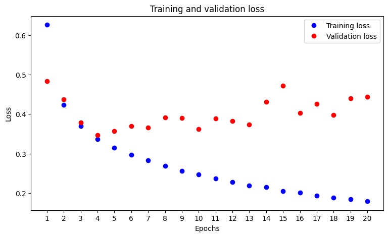

```python
# plot the training and validation loss
import matplotlib.pyplot as plt
plt.figure(figsize=(9, 5))
loss_values = history_dict2["loss"]
val_loss_values = history_dict2["val_loss"]
epochs = range(1, len(loss_values) + 1)
plt.plot(epochs, loss_values, "bo", label="Training loss")
plt.plot(epochs, val_loss_values, "ro", label="Validation loss")
plt.xlabel("Epochs")
plt.xticks(epochs)
plt.ylabel("Loss")
plt.legend()
plt.title("Training and validation loss")
```

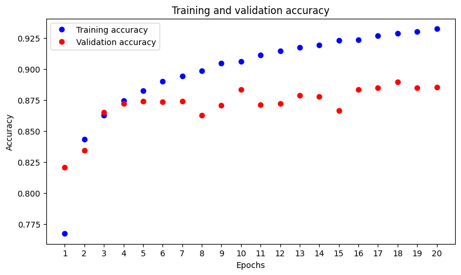

```python
# plot the training and validation accuracy
import matplotlib.pyplot as plt
plt.figure(figsize=(9, 5))
loss_values = history_dict2["accuracy"]
val_loss_values = history_dict2["val_accuracy"]
epochs = range(1, len(loss_values) + 1)
plt.plot(epochs, loss_values, "bo", label="Training accuracy")
plt.plot(epochs, val_loss_values, "ro", label="Validation accuracy")
plt.xlabel("Epochs")
plt.xticks(epochs)
plt.ylabel("Accuracy")
plt.legend()
plt.title("Training and validation accuracy")
```

### 3.2.3:Identify the best set of weights

The best set of weights for this model is at the end of epoch 4, where the validation loss reached its minimum value of 0.3468, indicating the optimal balance between learning from the training data and generalizing to the validation data.  
the plot of Training and validation loss clearly shows that at the beginning of the training(at the epoch 4) the data on validation set start overfitting. this indicate that this model with 3 layers is capturing many outliers which cause to overfitting.

## 3.3 Model3

### 3.3.1: Create Model 3:

as we sow in the previous model, increasing number of layers or neurons, did not increase in the model performance. so in the last model I will try to keep the model simple.with 1 hidden layer and 100 fully connected neurons.

```python
model3 = keras.Sequential([
    layers.Dense(100, activation="relu"),
    layers.Dense(10, activation="softmax")
])
```

```python
model3.compile(optimizer="rmsprop",
                loss="sparse_categorical_crossentropy",
                metrics=["accuracy"])
```

```python
history3 = model3.fit(partial_x_train,
                    partial_y_train,
                    epochs=10,
                    batch_size=32,
                    validation_data=(x_val, y_val),
                    callbacks=[model_checkpoint_callback])

history_dict3 = history3.history
history_dict3.keys()
```

```
dict_keys(['loss', 'accuracy', 'val_loss', 'val_accuracy'])
```

### 3.3.2: plotting the training and validation loss and accuracy for model 3

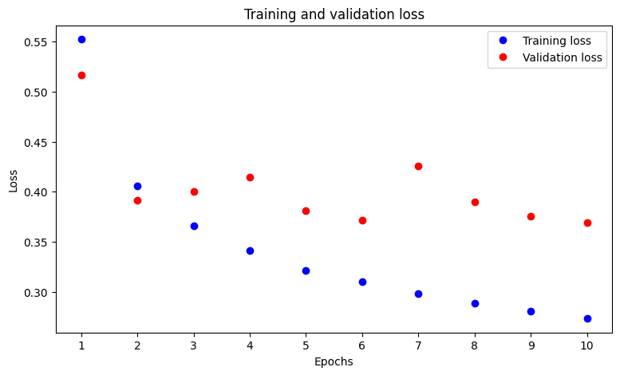

```python
# plot the training and validation loss
import matplotlib.pyplot as plt
plt.figure(figsize=(9, 5))
loss_values = history_dict3["loss"]
val_loss_values = history_dict3["val_loss"]
epochs = range(1, len(loss_values) + 1)
plt.plot(epochs, loss_values, "bo", label="Training loss")
plt.plot(epochs, val_loss_values, "ro", label="Validation loss")
plt.xlabel("Epochs")
plt.xticks(epochs)
plt.ylabel("Loss")
plt.legend()
plt.title("Training and validation loss")
```

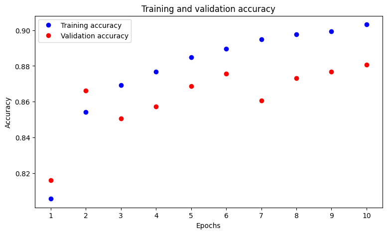

```python
# plot the training and validation accuracy
import matplotlib.pyplot as plt
plt.figure(figsize=(9, 5))
loss_values = history_dict3["accuracy"]
val_loss_values = history_dict3["val_accuracy"]
epochs = range(1, len(loss_values) + 1)
plt.plot(epochs, loss_values, "bo", label="Training accuracy")
plt.plot(epochs, val_loss_values, "ro", label="Validation accuracy")
plt.xlabel("Epochs")
plt.xticks(epochs)
plt.ylabel("Accuracy")
plt.legend()
plt.title("Training and validation accuracy")
```

### 3.4:

## My Model from lab 8:

I would like to plot the first model that I create it in Lab8, to compare with these 3 new models:

```python
from keras.callbacks import ModelCheckpoint
checkpoint_filepath = 'best_model.hdf5'  # Filepath where you want to save the model

model_checkpoint_callback = ModelCheckpoint(
    filepath=checkpoint_filepath,
    save_weights_only=False,  # Optionally save only weights instead of the full model
    monitor='val_loss',
    mode='min',  # Monitor validation loss and save on minimum
    save_best_only=True)
```

```python
model = keras.Sequential([
    layers.Dense(512, activation="relu"),
    layers.Dense(10, activation="softmax")
])
model.compile(optimizer="rmsprop",
                loss="sparse_categorical_crossentropy",
                metrics=["accuracy"])
```

```python
history = model.fit(partial_x_train,
                    partial_y_train,
                    epochs=10,
                    batch_size=100,
                    validation_data=(x_val, y_val))

history_dict = history.history
history_dict.keys()
```

```
dict_keys(['loss', 'accuracy', 'val_loss', 'val_accuracy'])
```

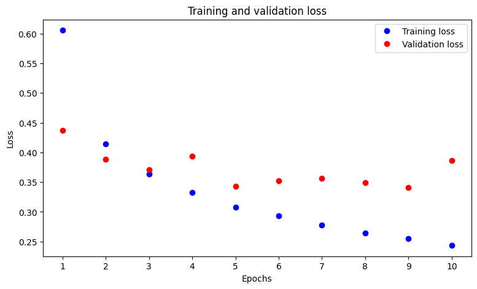

```python
# plot the training and validation loss
import matplotlib.pyplot as plt
plt.figure(figsize=(9, 5))
loss_values = history_dict["loss"]
val_loss_values = history_dict["val_loss"]
epochs = range(1, len(loss_values) + 1)
plt.plot(epochs, loss_values, "bo", label="Training loss")
plt.plot(epochs, val_loss_values, "ro", label="Validation loss")
plt.xlabel("Epochs")
plt.xticks(epochs)
plt.ylabel("Loss")
plt.legend()
plt.title("Training and validation loss")
```

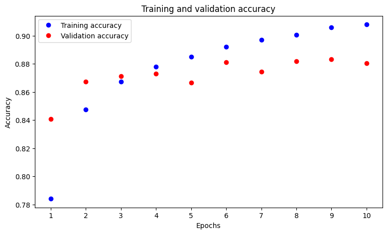

```python
# plot the training and validation accuracy
import matplotlib.pyplot as plt
plt.figure(figsize=(9, 5))
loss_values = history_dict["accuracy"]
val_loss_values = history_dict["val_accuracy"]
epochs = range(1, len(loss_values) + 1)
plt.plot(epochs, loss_values, "bo", label="Training accuracy")
plt.plot(epochs, val_loss_values, "ro", label="Validation accuracy")
plt.xlabel("Epochs")
plt.xticks(epochs)
plt.ylabel("Accuracy")
plt.legend()
plt.title("Training and validation accuracy")
```

## 3.5: comparing between the models:

```python
models = [model, model1, model2, model3]
model_names = ['My Model', 'Model 1', 'Model 2', 'Model 3']

for model, name in zip(models, model_names):
    try:
        loss, accuracy = model.evaluate(X_test, y_test, verbose=0)
        print(f"Results for {name}: Test Loss: {loss:.4f}, Test Accuracy: {accuracy:.4f}")
    except Exception as e:
        print(f"Error evaluating {name}: {e}")
```

```
Results for My Model: Test Loss: 0.3453, Test Accuracy: 0.8849
Results for Model 1: Test Loss: 0.3403, Test Accuracy: 0.8919
Results for Model 2: Test Loss: 0.3777, Test Accuracy: 0.8922
Results for Model 3: Test Loss: 0.3453, Test Accuracy: 0.8849
```

Before giving more details on the models lets check the features for each of them:

| Specification | My Model | Model 1 | Model 2 | Model 3 |
| --- | --- | --- | --- | --- |
| **First Layer** | Dense(512, relu) | Dense(1024, relu) | Dense(512, relu) | Dense(100, relu) |
| **Second Layer** | Dense(10, softmax) | Dense(10, softmax) | Dense(256, relu) | Dense(10, softmax) |
| **Third Layer** | - | - | Dense(128, relu) | - |
| **Fourth Layer** | - | - | Dense(10, softmax) | - |
| **Epochs** | 10 | 20 | 20 | 10 |
| **Batch Size** | 100 | 128 | 128 | 32 |

**Layers** Trying to change the number of layers (from 1 to 3 layers), the model with more layers had a minor improvement which is not worth for which we have to create a complicated layer. Hence I concluded that, 1 layer of hidden layer and 1 layer of class is a better option.

**Epochs** Number of epochs, I tried many times to manipulate the number of epochs by increasing and decreasing the number of epochs, while decreasing the number of epochs caused the model to perform faster, the model did not perform well. On the other hand, increasing the number of epochs (up to 20), it took more time to execute and toward the end of the loop, there was over fitting, so I concluded the best thing was to take a value in that does not cause a bottle neck.

**Detailed Analysis** My Model & Model 3: Both have identical Test Loss (0.3453) and Test Accuracy (0.8849). This similarity suggests that despite any architectural differences, their capacity to generalize and their performance on the test set are equivalent. This could imply a saturation point for the complexity needed to learn from the given dataset, or that both models are equally effective/ineffective at capturing the underlying patterns in the data.

Model 1: Shows a slight improvement over "My Model" and "Model 3" with a Test Loss of 0.3403 and a Test Accuracy of 89.19%. The improvement in both metrics suggests that whatever architectural or training parameter differences exist between Model 1 and the others (e.g., more neurons, different batch size, more epochs), they have contributed positively to the model's ability to generalize. This model strikes a good balance between learning from the training data and generalizing to new data.

Model 2: Despite having the highest Test Accuracy (89.22%), it also has the highest Test Loss (0.3777) among the models. This indicates a slightly more complex relationship; while it's slightly better at correctly classifying test data, the confidence (as indirectly suggested by the loss) in those classifications is lower on average compared to Model 1. This could be due to overfitting or an architecture that's more sensitive to the specific data points it gets wrong.

**My Recommendation:**

Choosing "Model 3" as the best option based on the closeness of the training and validation metrics in the plots is a sound decision. This closeness indicates that "Model 3" has achieved a good balance between learning from the training data and generalizing to unseen data, which is crucial for building robust machine learning models. Here's a simple insight into why "Model 3" stands out:

## Step 4: With the best model chosen above, and using its best weights as found above , run the evaluation as requested

```python
from keras.callbacks import ModelCheckpoint
checkpoint_filepath = 'best_model.hdf5'  # Filepath where you want to save the model

model_checkpoint_callback = ModelCheckpoint(
    filepath=checkpoint_filepath,
    save_weights_only=False,  # Optionally save only weights instead of the full model
    monitor='val_loss',
    mode='min',  # Monitor validation loss and save on minimum
    save_best_only=True)
```

```python
from tensorflow.keras.models import load_model

# Load the saved model
best_model = load_model('best_model.hdf5')

# Evaluate the model on the test data
test_loss, test_accuracy = best_model.evaluate(X_test, y_test, verbose=1)

# Print the results
print(f'Test Loss: {test_loss:.4f}')
print(f'Test Accuracy: {test_accuracy:.4f}')
```

```
Test Loss: 0.4124
Test Accuracy: 0.8860
```

```python
predictions = best_model.predict(X_test)
predicted_classes = np.argmax(predictions, axis=1)
```

```python
# Accuracy
accuracy = accuracy_score(y_test, predicted_classes)
print(f'Accuracy: {accuracy:.4f}')

# Precision
precision = precision_score(y_test, predicted_classes, average='weighted')  # You can change average method
print(f'Precision: {precision:.4f}')

# Recall
recall = recall_score(y_test, predicted_classes, average='weighted')  # You can change average method
print(f'Recall: {recall:.4f}')

# F1 Score
f1 = f1_score(y_test, predicted_classes, average='weighted')  # You can change average method
print(f'F1 Score: {f1:.4f}')

# Classification Report
print("Classification Report:")
print(classification_report(y_test, predicted_classes))
```

```
Accuracy: 0.8860
Precision: 0.8884
Recall: 0.8860
F1 Score: 0.8864
Classification Report:
              precision    recall  f1-score   support

           0       0.87      0.75      0.81      1000
           1       0.99      0.98      0.98      1000
           2       0.80      0.83      0.81      1000
           3       0.90      0.92      0.91      1000
           4       0.82      0.83      0.83      1000
           5       0.98      0.93      0.95      1000
           6       0.69      0.74      0.72      1000
           7       0.93      0.95      0.94      1000
           8       0.98      0.96      0.97      1000
           9       0.94      0.97      0.95      1000

    accuracy                           0.89     10000
   macro avg       0.89      0.89      0.89     10000
weighted avg       0.89      0.89      0.89     10000
```

**Comparision between My Model and Best Model**

[output not shown]

After Evaluating this, I found out that the accuracy of my model (lab 8) is better than this. although these two models are similar, they have same layers and activation function, the difference is only in number of neurons, my model has more number of neurons thus higher accuracy.